# Rent and income in Barcelona: and unequal relationship

```python
rentinc_sarria
```

|  | Year | Term | District | Neighbourhood | Monthly Rent | Monthly Income |
| --- | --- | --- | --- | --- | --- | --- |
| 96 | 2023 | 2 | Sarrià-Sant Gervasi | les Tres Torres | 1859.8 | 3690.03 |
| 95 | 2023 | 2 | Sarrià-Sant Gervasi | Sarrià | 1559.9 | 3208.19 |
| 94 | 2023 | 2 | Sarrià-Sant Gervasi | Vallvidrera, el Tibidabo i les Planes | 1240.9 | 2553.22 |
| 99 | 2023 | 2 | Sarrià-Sant Gervasi | el Putxet i el Farró | 1242.8 | 2549.78 |

```python
rentinc_ciutatvella
```

|  | Year | Term | District | Neighbourhood | Monthly Rent | Monthly Income |
| --- | --- | --- | --- | --- | --- | --- |
| 76 | 2023 | 2 | Ciutat Vella | Sant Pere, Santa Caterina i la Ribera | 1107.5 | 1506.46 |
| 74 | 2023 | 2 | Ciutat Vella | el Barri Gòtic | 1293.9 | 1416.38 |
| 75 | 2023 | 2 | Ciutat Vella | la Barceloneta | 1002.2 | 1332.21 |
| 73 | 2023 | 2 | Ciutat Vella | el Raval | 905.4 | 1011.11 |

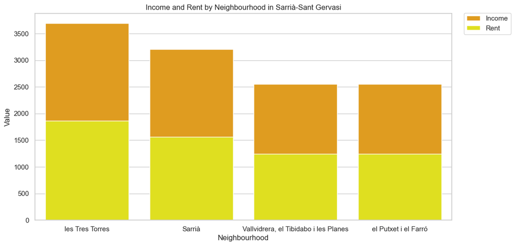

```python
#Plot for Sarrià-Sant Gervasi
#I set the style
sns.set(style="whitegrid")

#I create a figure where the graph is going to be placed
plt.figure(figsize=(12, 6))

#I create the bar plot
bar_plot = sns.barplot(x='Neighbourhood', y='Monthly Income', data=rentinc_sarria, label='Income', color='orange')
bar_plot = sns.barplot(x='Neighbourhood', y='Monthly Rent', data=rentinc_sarria, label='Rent', color='yellow')

# Customize the plot
plt.title('Income and Rent by Neighbourhood in Sarrià-Sant Gervasi')
plt.xlabel('Neighbourhood')
plt.ylabel('Value')
plt.legend(loc='upper right', bbox_to_anchor=(1.15, 1.02))
#I save it as a PNG
plt.savefig('sarria',dpi=300, bbox_inches='tight')
# Show the plot
plt.show()
```

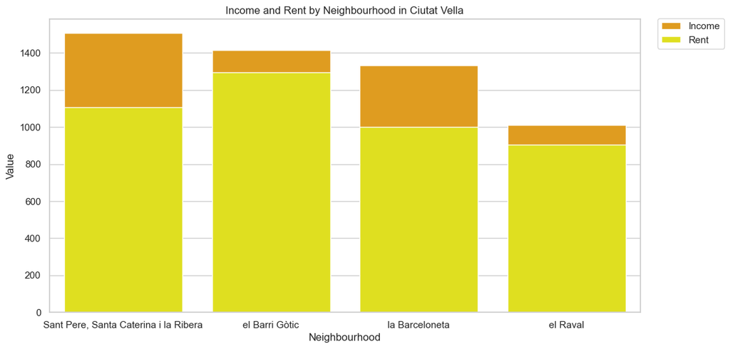

```python
#Plot for Ciutat Vella
#I set the style
sns.set(style="whitegrid")

# Create the dodged bar plot
plt.figure(figsize=(12, 6))

# Plot the dodged bar plot
bar_plot = sns.barplot(x='Neighbourhood', y='Monthly Income', data=rentinc_ciutatvella, label='Income', color='orange')
bar_plot = sns.barplot(x='Neighbourhood', y='Monthly Rent', data=rentinc_ciutatvella, label='Rent', color='yellow')

# Customize the plot
plt.title('Income and Rent by Neighbourhood in Ciutat Vella')
plt.xlabel('Neighbourhood')
plt.ylabel('Value')
plt.legend(loc='upper right', bbox_to_anchor=(1.15, 1.02))
#I save it as a PNG
plt.savefig('ciutat vella',dpi=300, bbox_inches='tight')
# Show the plot
plt.show()
```

We continue exploring a little bit more. We want to see the specific values for La Barceloneta.

```python
#I use the command print
print(rent_income['Neighbourhood'].unique())
```

```
['el Raval' 'el Barri Gòtic' 'la Barceloneta'
 'Sant Pere, Santa Caterina i la Ribera' 'el Fort Pienc'
 'la Sagrada Família' "la Dreta de l'Eixample"
 "l'Antiga Esquerra de l'Eixample" "la Nova Esquerra de l'Eixample"
 'Sant Antoni' 'el Poble Sec' 'la Marina del Prat Vermell'
 'la Marina de Port' 'la Font de la Guatlla' 'Hostafrancs' 'la Bordeta'
 'Sants - Badal' 'Sants' 'les Corts' 'la Maternitat i Sant Ramon'
 'Pedralbes' 'Vallvidrera, el Tibidabo i les Planes' 'Sarrià'
 'les Tres Torres' 'Sant Gervasi - la Bonanova' 'Sant Gervasi - Galvany'
 'el Putxet i el Farró' 'Vallcarca i els Penitents' 'el Coll' 'la Salut'
 'la Vila de Gràcia' "el Camp d'en Grassot i Gràcia Nova"
 'el Baix Guinardó' 'Can Baró' 'el Guinardó' "la Font d'en Fargues"
 'el Carmel' 'la Teixonera' 'Sant Genís dels Agudells' 'Montbau'
 "la Vall d'Hebron" 'la Clota' 'Horta' 'Vilapicina i la Torre Llobeta'
 'Porta' 'el Turó de la Peira' 'Can Peguera' 'la Guineueta' 'Canyelles'
 'les Roquetes' 'Verdun' 'la Prosperitat' 'la Trinitat Nova' 'Torre Baró'
 'Ciutat Meridiana' 'Vallbona' 'la Trinitat Vella' 'Baró de Viver'
 'el Bon Pastor' 'Sant Andreu' 'la Sagrera' 'el Congrés i els Indians'
 'Navas' "el Camp de l'Arpa del Clot" 'el Clot'
 'el Parc i la Llacuna del Poblenou' 'la Vila Olímpica del Poblenou'
 'el Poblenou' 'Diagonal Mar i el Front Marítim del Poblenou'
 'el Besòs i el Maresme' 'Provençals del Poblenou'
 'Sant Martí de Provençals' 'la Verneda i la Pau']
```

```python
#I can see the specific results for 'La Barceloneta'
specific_value_row=rent_income.loc[rent_income['Neighbourhood']=='la Barceloneta']
```

```python
specific_value_row
```

|  | Year | Term | District | Neighbourhood | Monthly Rent | Monthly Income |
| --- | --- | --- | --- | --- | --- | --- |
| 2 | 2023 | 1 | Ciutat Vella | la Barceloneta | 978.7 | 1332.21 |
| 75 | 2023 | 2 | Ciutat Vella | la Barceloneta | 1002.2 | 1332.21 |

```python
#I rename this dataframe as we will want to merge it later with the datasets from previous years
la_Barceloneta23 =specific_value_row.copy()
```

To conclude the analysis, I aim to create a line graph illustrating the changes in rent over time, focusing specifically on La Barceloneta. I will look into the evolution of the price per m2. To do so I will need to retrieve new data from previous years. I decided to look at data from 2019, 2020, 2021 and 2022, since this time period includes the pandemic, when prices supposedly dropped. Again this data is provided by Barcelona's City Hall Open Data Service: https://ajuntament.barcelona.cat/estadistica/angles/Estadistiques_per_temes/Habitatge_i_mercat_immobiliari/Mercat_immobiliari/Habitatges_lloguer/a2019/index.htm

```python
#I load the new datasets
rent22=pd.read_csv('rent22.csv')
rent21=pd.read_csv('rent21.csv')
rent20=pd.read_csv('rent20.csv')
rent19=pd.read_csv('rent19.csv')
```

```python
rent22
```

|  | Any | Trimestre | Codi_Districte | Nom_Districte | Codi_Barri | Nom_Barri | Lloguer_mitja | Preu |
| --- | --- | --- | --- | --- | --- | --- | --- | --- |
| 0 | 2022 | 1 | 1 | Ciutat Vella | 1 | el Raval | Lloguer mitjà mensual (Euros/mes) | 917.0 |
| 1 | 2022 | 1 | 1 | Ciutat Vella | 2 | el Barri Gòtic | Lloguer mitjà mensual (Euros/mes) | 1181.6 |
| 2 | 2022 | 1 | 1 | Ciutat Vella | 3 | la Barceloneta | Lloguer mitjà mensual (Euros/mes) | 999.8 |
| 3 | 2022 | 1 | 1 | Ciutat Vella | 4 | Sant Pere, Santa Caterina i la Ribera | Lloguer mitjà mensual (Euros/mes) | 1022.8 |
| 4 | 2022 | 1 | 2 | Eixample | 5 | el Fort Pienc | Lloguer mitjà mensual (Euros/mes) | 957.9 |
| ... | ... | ... | ... | ... | ... | ... | ... | ... |
| 433 | 2022 | 3 | 10 | Sant Martí | 69 | Diagonal Mar i el Front Marítim del Poblenou | Lloguer mitjà per superfície (Euros/m2 mes) | 17.6 |
| 434 | 2022 | 3 | 10 | Sant Martí | 70 | el Besòs i el Maresme | Lloguer mitjà per superfície (Euros/m2 mes) | 12.4 |
| 435 | 2022 | 3 | 10 | Sant Martí | 71 | Provençals del Poblenou | Lloguer mitjà per superfície (Euros/m2 mes) | 14.8 |
| 436 | 2022 | 3 | 10 | Sant Martí | 72 | Sant Martí de Provençals | Lloguer mitjà per superfície (Euros/m2 mes) | 12.3 |
| 437 | 2022 | 3 | 10 | Sant Martí | 73 | la Verneda i la Pau | Lloguer mitjà per superfície (Euros/m2 mes) | 11.5 |

438 rows × 8 columns

```python
#I only want to know the value for €/m2, so we create a new dataset
Rentm2_22=rent22[rent22["Lloguer_mitja"]=='Lloguer mitjà per superfície (Euros/m2 mes)']
#I rename the columns and drop some of them
Rentm2_22=Rentm2_22.rename(columns={'Any':'Year','Trimestre':'Term','Nom_Districte':'District',
                                   'Nom_Barri':'Neighbourhood','Preu':'€/m2'})
Rentm2_22=Rentm2_22.drop(columns={'Codi_Districte','Codi_Barri','Lloguer_mitja'})
```

```python
Rentm2_22
```

|  | Year | Term | District | Neighbourhood | €/m2 |
| --- | --- | --- | --- | --- | --- |
| 73 | 2022 | 1 | Ciutat Vella | el Raval | 15.5 |
| 74 | 2022 | 1 | Ciutat Vella | el Barri Gòtic | 17.2 |
| 75 | 2022 | 1 | Ciutat Vella | la Barceloneta | 21.3 |
| 76 | 2022 | 1 | Ciutat Vella | Sant Pere, Santa Caterina i la Ribera | 15.3 |
| 77 | 2022 | 1 | Eixample | el Fort Pienc | 13.5 |
| ... | ... | ... | ... | ... | ... |
| 433 | 2022 | 3 | Sant Martí | Diagonal Mar i el Front Marítim del Poblenou | 17.6 |
| 434 | 2022 | 3 | Sant Martí | el Besòs i el Maresme | 12.4 |
| 435 | 2022 | 3 | Sant Martí | Provençals del Poblenou | 14.8 |
| 436 | 2022 | 3 | Sant Martí | Sant Martí de Provençals | 12.3 |
| 437 | 2022 | 3 | Sant Martí | la Verneda i la Pau | 11.5 |

219 rows × 5 columns

```python
#I look specifically at La Barceloneta
la_Barceloneta22=Rentm2_22.loc[Rentm2_22['Neighbourhood']=='la Barceloneta']
```

```python
la_Barceloneta22
```

|  | Year | Term | District | Neighbourhood | €/m2 |
| --- | --- | --- | --- | --- | --- |
| 75 | 2022 | 1 | Ciutat Vella | la Barceloneta | 21.3 |
| 221 | 2022 | 2 | Ciutat Vella | la Barceloneta | 16.6 |
| 367 | 2022 | 3 | Ciutat Vella | la Barceloneta | 17.6 |

I will take the exact same steps for rent21, rent20 & rent19. I first create a new dataset (to avoid changing the original), because I only want to keep the values referring to €/m2. I then rename the columns and drop the ones I don't need.

```python
rent21
```

|  | Any | Trimestre | Codi_Districte | Nom_Districte | Codi_Barri | Nom_Barri | Lloguer_mitja | Preu |
| --- | --- | --- | --- | --- | --- | --- | --- | --- |
| 0 | 2021 | 1 | 1 | Ciutat Vella | 1 | el Raval | Lloguer mitjà mensual (Euros/mes) | 759.2 |
| 1 | 2021 | 1 | 1 | Ciutat Vella | 2 | el Barri Gòtic | Lloguer mitjà mensual (Euros/mes) | 929.6 |
| 2 | 2021 | 1 | 1 | Ciutat Vella | 3 | la Barceloneta | Lloguer mitjà mensual (Euros/mes) | 808.9 |
| 3 | 2021 | 1 | 1 | Ciutat Vella | 4 | Sant Pere, Santa Caterina i la Ribera | Lloguer mitjà mensual (Euros/mes) | 879.4 |
| 4 | 2021 | 1 | 2 | Eixample | 5 | el Fort Pienc | Lloguer mitjà mensual (Euros/mes) | 918.0 |
| ... | ... | ... | ... | ... | ... | ... | ... | ... |
| 579 | 2021 | 4 | 10 | Sant Martí | 69 | Diagonal Mar i el Front Marítim del Poblenou | Lloguer mitjà per superfície (Euros/m2 mes) | 15.2 |
| 580 | 2021 | 4 | 10 | Sant Martí | 70 | el Besòs i el Maresme | Lloguer mitjà per superfície (Euros/m2 mes) | 10.8 |
| 581 | 2021 | 4 | 10 | Sant Martí | 71 | Provençals del Poblenou | Lloguer mitjà per superfície (Euros/m2 mes) | 13.8 |
| 582 | 2021 | 4 | 10 | Sant Martí | 72 | Sant Martí de Provençals | Lloguer mitjà per superfície (Euros/m2 mes) | 11.7 |
| 583 | 2021 | 4 | 10 | Sant Martí | 73 | la Verneda i la Pau | Lloguer mitjà per superfície (Euros/m2 mes) | 11.3 |

584 rows × 8 columns

```python
Rentm2_21=rent21[rent21["Lloguer_mitja"]=='Lloguer mitjà per superfície (Euros/m2 mes)']
Rentm2_21=Rentm2_21.rename(columns={'Any':'Year','Trimestre':'Term','Nom_Districte':'District',
                                   'Nom_Barri':'Neighbourhood','Preu':'€/m2'})
Rentm2_21=Rentm2_21.drop(columns={'Codi_Districte','Codi_Barri','Lloguer_mitja'})
```

```python
Rentm2_21
```

|  | Year | Term | District | Neighbourhood | €/m2 |
| --- | --- | --- | --- | --- | --- |
| 73 | 2021 | 1 | Ciutat Vella | el Raval | 12.8 |
| 74 | 2021 | 1 | Ciutat Vella | el Barri Gòtic | 12.3 |
| 75 | 2021 | 1 | Ciutat Vella | la Barceloneta | 15.5 |
| 76 | 2021 | 1 | Ciutat Vella | Sant Pere, Santa Caterina i la Ribera | 13.3 |
| 77 | 2021 | 1 | Eixample | el Fort Pienc | 12.9 |
| ... | ... | ... | ... | ... | ... |
| 579 | 2021 | 4 | Sant Martí | Diagonal Mar i el Front Marítim del Poblenou | 15.2 |
| 580 | 2021 | 4 | Sant Martí | el Besòs i el Maresme | 10.8 |
| 581 | 2021 | 4 | Sant Martí | Provençals del Poblenou | 13.8 |
| 582 | 2021 | 4 | Sant Martí | Sant Martí de Provençals | 11.7 |
| 583 | 2021 | 4 | Sant Martí | la Verneda i la Pau | 11.3 |

292 rows × 5 columns

```python
la_Barceloneta21=Rentm2_21.loc[Rentm2_21['Neighbourhood']=='la Barceloneta']
```

```python
la_Barceloneta21
```

|  | Year | Term | District | Neighbourhood | €/m2 |
| --- | --- | --- | --- | --- | --- |
| 75 | 2021 | 1 | Ciutat Vella | la Barceloneta | 15.5 |
| 221 | 2021 | 2 | Ciutat Vella | la Barceloneta | 15.9 |
| 367 | 2021 | 3 | Ciutat Vella | la Barceloneta | 16.3 |
| 513 | 2021 | 4 | Ciutat Vella | la Barceloneta | 16.4 |

```python
rent20
```

|  | Any | Trimestre | Codi_Districte | Nom_Districte | Codi_Barri | Nom_Barri | Lloguer_mitja | Preu |
| --- | --- | --- | --- | --- | --- | --- | --- | --- |
| 0 | 2020 | 1 | 1 | Ciutat Vella | 1 | el Raval | Lloguer mitjà mensual (Euros/mes) | 864.5 |
| 1 | 2020 | 1 | 1 | Ciutat Vella | 2 | el Barri Gòtic | Lloguer mitjà mensual (Euros/mes) | 1110.2 |
| 2 | 2020 | 1 | 1 | Ciutat Vella | 3 | la Barceloneta | Lloguer mitjà mensual (Euros/mes) | 899.5 |
| 3 | 2020 | 1 | 1 | Ciutat Vella | 4 | Sant Pere, Santa Caterina i la Ribera | Lloguer mitjà mensual (Euros/mes) | 1030.0 |
| 4 | 2020 | 1 | 2 | Eixample | 5 | el Fort Pienc | Lloguer mitjà mensual (Euros/mes) | 1059.9 |
| ... | ... | ... | ... | ... | ... | ... | ... | ... |
| 579 | 2020 | 4 | 10 | Sant Martí | 69 | Diagonal Mar i el Front Marítim del Poblenou | Lloguer mitjà per superfície (Euros/m2 mes) | 17.5 |
| 580 | 2020 | 4 | 10 | Sant Martí | 70 | el Besòs i el Maresme | Lloguer mitjà per superfície (Euros/m2 mes) | 11.7 |
| 581 | 2020 | 4 | 10 | Sant Martí | 71 | Provençals del Poblenou | Lloguer mitjà per superfície (Euros/m2 mes) | 12.6 |
| 582 | 2020 | 4 | 10 | Sant Martí | 72 | Sant Martí de Provençals | Lloguer mitjà per superfície (Euros/m2 mes) | 11.8 |
| 583 | 2020 | 4 | 10 | Sant Martí | 73 | la Verneda i la Pau | Lloguer mitjà per superfície (Euros/m2 mes) | 11.6 |

584 rows × 8 columns

```python
Rentm2_20=rent20[rent20["Lloguer_mitja"]=='Lloguer mitjà per superfície (Euros/m2 mes)']
Rentm2_20=Rentm2_20.rename(columns={'Any':'Year','Trimestre':'Term','Nom_Districte':'District',
                                   'Nom_Barri':'Neighbourhood','Preu':'€/m2'})
Rentm2_20=Rentm2_20.drop(columns={'Codi_Districte','Codi_Barri','Lloguer_mitja'})
```

```python
Rentm2_20
```

|  | Year | Term | District | Neighbourhood | €/m2 |
| --- | --- | --- | --- | --- | --- |
| 73 | 2020 | 1 | Ciutat Vella | el Raval | 14.5 |
| 74 | 2020 | 1 | Ciutat Vella | el Barri Gòtic | 14.2 |
| 75 | 2020 | 1 | Ciutat Vella | la Barceloneta | 17.5 |
| 76 | 2020 | 1 | Ciutat Vella | Sant Pere, Santa Caterina i la Ribera | 14.9 |
| 77 | 2020 | 1 | Eixample | el Fort Pienc | 14.6 |
| ... | ... | ... | ... | ... | ... |
| 579 | 2020 | 4 | Sant Martí | Diagonal Mar i el Front Marítim del Poblenou | 17.5 |
| 580 | 2020 | 4 | Sant Martí | el Besòs i el Maresme | 11.7 |
| 581 | 2020 | 4 | Sant Martí | Provençals del Poblenou | 12.6 |
| 582 | 2020 | 4 | Sant Martí | Sant Martí de Provençals | 11.8 |
| 583 | 2020 | 4 | Sant Martí | la Verneda i la Pau | 11.6 |

292 rows × 5 columns